# CSCI E-63C: Week 2 Assignment

Tony McGovern

12 September 2017

# Banknote Authentication

In this problem, I load, explore, visualize, and comment on data that describes bank notes that are both counterfeit and not counterfeit.

```r
# load data
url <- "http://archive.ics.uci.edu/ml/machine-learning-databases/00267/data_banknote_authentication.txt"
banknote.df <- read_delim(url,",", col_names = c("moment2","moment3","moment4","entropy","class"))
```

Describe the data set attributes:

| col_name | attribute_name |
| --- | --- |
| moment2 | variance of Wavelet Transformed image (continuous) |
| moment3 | skewness of Wavelet Transformed image (continuous) |
| moment4 | curtosis of Wavelet Transformed image (continuous) |
| entropy | entropy of image (continuous) |
| class | class (integer) |

The data set has 1372 rows or observations and 5 columns or variables. The predictor variables are *moment2*, *moment3*, *moment4*, and *entropy*. The response variable is *class*.

Now present a summary of the data, complete with data types and measures of central tendency and dispersion: (Note: I convert the *class* variable from an integer to a factor. I run this analysis from the perspective of determining which banknotes are counterfeit: ‘0’ equals ‘no’ (not counterfeit), ‘1’ equals yes (counterfeit).)

```r
banknote.df$class <- factor(banknote.df$class, levels=c(0,1),
                            labels=c("no", "yes"))


# summarize data
banknote.skim <- data.frame(skim(banknote.df))
banknote.skim$value <- as.integer(banknote.skim$value)

banknote.skim.tranform <- banknote.skim %>%
  filter(stat %in% c("missing","complete","n","n_unique","min","max","median","sd")) %>%
  spread("stat","value") %>%
  select(-c(level))

kable(banknote.skim.tranform)
```

| var | type | complete | max | median | min | missing | n | n_unique | sd |
| --- | --- | --- | --- | --- | --- | --- | --- | --- | --- |
| class | factor | 1372 | NA | NA | NA | 0 | 1372 | 2 | NA |
| entropy | numeric | 1372 | 2 | 0 | -8 | 0 | 1372 | NA | 2 |
| moment2 | numeric | 1372 | 6 | 0 | -7 | 0 | 1372 | NA | 2 |
| moment3 | numeric | 1372 | 12 | 2 | -13 | 0 | 1372 | NA | 5 |
| moment4 | numeric | 1372 | 17 | 0 | -5 | 0 | 1372 | NA | 4 |

Now visualize the data:

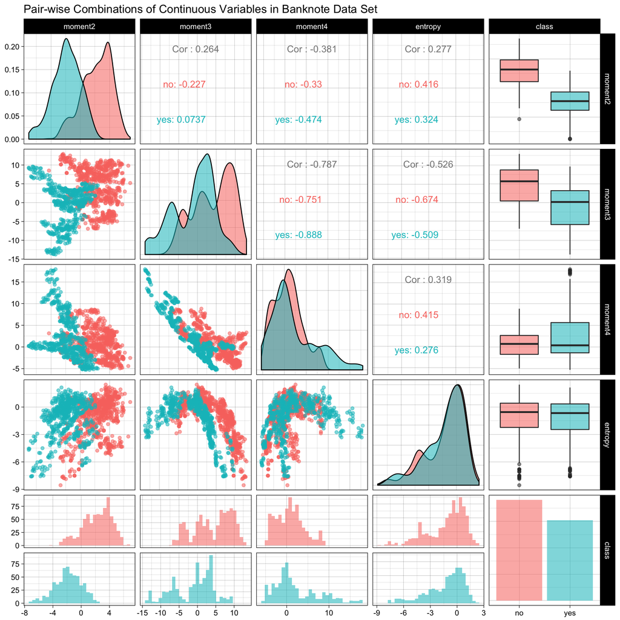

```r
# generate pair-wise XY-scatterplots of each pair of continuous variables including the outcome using color and/or shape (use pairs function)

ggpairs(banknote.df, aes(color = class, alpha = 0.9)) +
  labs(
    title = "Pair-wise Combinations of Continuous Variables in Banknote Data Set"
  ) +
  theme_linedraw()
```

The scatterplot above shows a few interesting features:

- the distribution of *moment2* and *moment3* seem to be more “normal” than the other variables
- *moment3* and *moment4* seems to have a strong, negative linear correlation between them
- there seems to be a visible distinction in how *moment2* and *moment3* are grouped by those that are counterfeit (“Yes”) and those that are not counterfeit (“No”)

Given that *moment2* and *moment3* seem to have close to constant variability, much of the variability in the *class* variable can probably be explained by these two variables. In other words *moment2* and *moment3* are more likely to be more predictive with respect to discriminating real and counterfeit bank notes.

This is probably not an easy problem to solve given that the data really only have one metric, *Wavelet Transformed image*, and the variables are really just a transformation of the 2nd to 4th moments of that metric about the mean. Different measurements of the bank notes may yield better predictions.

My guess is that there would be a high error rate in the data set, at about 75%. And since there is only one metric being used to determine counterfeit bank notes, I would expect a high error rate. The tradeoffs with a given level of error comes down to what would happen when Type I and Type II errors occur.

Assume the null hypothesis is that a sample bank note is not counterfeit. For Type I errors, rejecting the null hypothesis when it is true will lead bank examiners to conclude that there are fewer counterfeit bank notes in circulation, thus raising the cost of penalty from the government if those bank notes are traced back to the bank.

For Type II errors, failing to reject the null hypothesis when it is false will also be costly as the bank may take more bank notes out of circulation than is necessary. Though this cost would almost certainly be less than the cost borne by Type I errors.

# Abalone

In this problem, I load, explore, visualize, and comment on data that describes the age of snails with a few other variables.

```r
# load data
url <- "http://archive.ics.uci.edu/ml/machine-learning-databases/abalone/abalone.data"
abalone.df <- read_delim(url, ",", col_names = c("sex","length","diameter","height","weight.whole","weight.shucked","weight.viscera","weight.shell","rings"))
```

Describe the data set attributes:

```r
# name the data set attributes
attributes <- data.frame(
  "col_name" = c(
    "sex",
    "length",
    "diameter",
    "height",
    "weight.whole",
    "weight.shucked",
    "weight.viscera",
    "weight.shell",
    "rings"),
  "attribute_name" = c(
    "Sex",
    "Length",
    "Diameter",
    "Height",
    "Whole Weight",
    "Shucked Weight",
    "Viscera Weight",
    "Shell Weight",
    "Rings"
))

kable(attributes)
```

| col_name | attribute_name |
| --- | --- |
| sex | Sex |
| length | Length |
| diameter | Diameter |
| height | Height |
| weight.whole | Whole Weight |
| weight.shucked | Shucked Weight |
| weight.viscera | Viscera Weight |
| weight.shell | Shell Weight |
| rings | Rings |

The `abalone` data set has 4177 rows or observations and 9 columns or variables. The predictor variables are *sex*, *length*, *diameter*, *height*, *weight.whole*, *weight.shucked*, *weight.viscera*, and *weight.shell*. The response variable is *rings*. The *sex* variable is a categorical dimension with three distinct values: “F”, “I”, and “M”. All other variables are continuous variables.

Now present a summary of the data, complete with data types and measures of central tendency and dispersion:

```r
# convert 'sex' variable from a character to a factor
abalone.df$sex <- factor(abalone.df$sex)

# summarize data
abalone.skim <- data.frame(skim(abalone.df))
abalone.skim$value <- as.integer(abalone.skim$value)

abalone.skim.tranform <- abalone.skim %>%
  filter(stat %in% c("missing","complete","n","n_unique","min","max","median","sd")) %>%
  spread("stat","value") %>%
  select(-c(level))

kable(abalone.skim.tranform)
```

| var | type | complete | max | median | min | missing | n | n_unique | sd |
| --- | --- | --- | --- | --- | --- | --- | --- | --- | --- |
| diameter | numeric | 4177 | 0 | 0 | 0 | 0 | 4177 | NA | 0 |
| height | numeric | 4177 | 1 | 0 | 0 | 0 | 4177 | NA | 0 |
| length | numeric | 4177 | 0 | 0 | 0 | 0 | 4177 | NA | 0 |
| rings | integer | 4177 | 29 | 9 | 1 | 0 | 4177 | NA | 3 |
| sex | factor | 4177 | NA | NA | NA | 0 | 4177 | 3 | NA |
| weight.shell | numeric | 4177 | 1 | 0 | 0 | 0 | 4177 | NA | 0 |
| weight.shucked | numeric | 4177 | 1 | 0 | 0 | 0 | 4177 | NA | 0 |
| weight.viscera | numeric | 4177 | 0 | 0 | 0 | 0 | 4177 | NA | 0 |
| weight.whole | numeric | 4177 | 2 | 0 | 0 | 0 | 4177 | NA | 0 |

Now visualize the data:

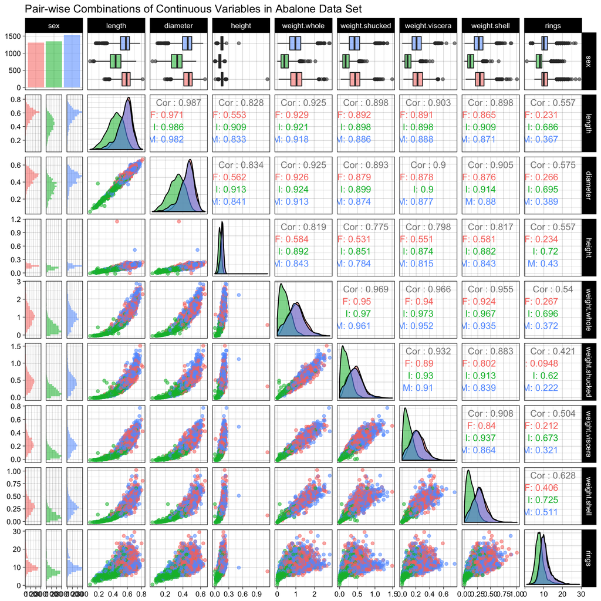

```r
ggpairs(abalone.df, aes(color = sex, alpha = 0.9)) +
  labs(
    title = "Pair-wise Combinations of Continuous Variables in Abalone Data Set"
  ) +
  theme_linedraw()
```

The scatterplot above shows a few interesting features: